## Introduction

This is a tutorial of a genome-wide association study (GWAS). In essence, a genome-wide association study is an examination of a genome-wide set of vatiants in different individuals to see if any variant is associated with a phenotype.

A GWAS study investigates a number of individuals for which is available

- genotype information on a genome-wide scale
- phenotype information

By using this information, a GWAS compares the DNA of individuals having a certain phenotype. For instance,some individuals have a disease (cases) and similar individuals may not have the disease (controls). If one type of a genetic variant (one allele) is more frequent in cases, then the variant is identified as being associated with the disease. The associated SNPs are then considered to mark a region of the human genome that may influence the risk of developing a disease.

This tutorial provides a workflow of performing a GWAS on celiac disease to identify loci that are associated with increased risk to develop the disease. This information can be further used to investigate the molecular pathways that genes from the GWAS-identified loci are involved. Celiac disease is an autoimmune disorder that can occur in genetically predisposed individuals and it affects 1 in 100 individuals worldwide. It is known that gluten consumption leads to damage in the small intestine, resulting in poor absorbance of nutrients from the human body.

This tutorial requires you to be familiar with R language, but not necessarily, as answers are provided for those who are not familiar with R code. Furthermore, questions are provided to get familiar with every step of the GWAS workflow. Remember that doing associations is the same as doing statistics so a relatively small knowledge of maths is required. Please make an effort to understand the equations that are used here. Most of the maths are encoded in the R code that is provided by the tutorial.

Because of the sensitive nature of using individual’s genetic data, *publicly* available genotypes and *simulated* phenotypes will be used in this tutorial. However, the workflow essentially remains the same if you use a dataset that contains real phenotypes.

The GWAS data that will be generated for *Celiac disease* can be used for follow-up analysis in the next classes. To ensure power, a quantative phenotype was simulated, but you can also do this analysis on a discrete phenotype.

## Data used in this tutorial.

The data in use is in the binary *plink* format.

BED file The bed files are encoded in a binary format.It is a primary representation of genotype calla at biallelic variants. Must be accompanied by BIM and FAM files.

BIM files The fields in a BIM file are: Chromosome SNP marker ID Genetic distance Physical position Allele 1 Allele 2

FAM files The fields in a FAM file are: Family ID Individual ID Paternal ID Maternal ID Sex (1 = male; 2 = female; other = unknown) Phenotype (1 = control; 2 = case; 0 = unknown)

Plink is a command-line program that allows a user to perform an integrated GWAS, but is not very transparent in its methods.For more information on plink, please, use the link: https://www.cog-genomics.org/plink2. Therefore, in this tutorial, we are doing a very similar analysis using R language.

We will load the plink genotype and phenotype matrix using the R package `BEDMatrix`. The rest of the analysis will be done using *vanilla* R. Some commands that are provided will be complicated (such as is the nature of R in some cases), but the comments in the code explain the steps that are taken.

Our data consists of $512$ individuals, and $131,118$ *bi-allelic* genetic variants.

## Downloading the data

You can download a zip file from [here](http://molgenis.org/downloads/gwas_tutorial_AvdG_2017/celiac_gwas.zip)

Make sure this zip file is unpacked in a unique folder. in our case this is the folder `genotypes`

Then point the r working directory to this folder using `setwd`.

### Data conventions

If we want to do statistics on genotype data, these data are needed to be numerically encoded. In this tutorial, we choose to explain the *additive* effect of a certain allele. For instance, take a hypothetical SNP `rs12` which has two alleles (remember the biallelic variants): `A' and`C’. The number of indivduals that have a certain genotype of `rs12’ are shown in the table below.

```r
a <- data.frame(genotype=c("AA","AC", "CC"), count=c(497,12,3))
a
```

```
##   genotype count
## 1       AA   497
## 2       AC    12
## 3       CC     3
```

The `A` allele is more prevalent so we call this as the major allele, and the `C` allele is then the minor allele. We then encode the genotypes `AA`, `AC` and `CC` for each individual as $0, 1, 2$ respectively. This is the same as counting how many individuals have the `C` allele.

Coding alleles numericaly allows an investigator to do regression on the additive relationship of an allele and a phenotype. Dominant, recessive or epistatic effects are also present in biology, but we do not consider them in this tutorial.

## GWAS steps

The following steps are taken to perform a GWAS:

1. Import the data in R and explore them
2. Quality control per SNP
   1. Remove SNPs with minor allele frequency (MAF) < 0.01
   2. Remove SNPs that deviate from Hardy Weinberg equilibrium (HWE) using a P threshold < 1e-6
   3. Remove SNPs with missing genotype rate < 0.99
3. Quality control per individual
   1. Identify and remove related individuals
   2. Perform principal component analysis (PCA)and plot the first two components to identify and remove population outliers
4. Perform genome-wide association testing
   1. do initial association analysis, linear
   2. do association analysis, logistic (Bonus)
   3. prepare a manhattan plot

Before we start, make sure you install the `BEDMatrix` package:

```
install.packages("BEDMatrix")
```

And again, make sure your working directory is the same as where the data is, using `setwd()`

## Step 1. Import the data in R and explore them

### Download and have a look at the data

First, download the data and set the R working directory to this directory as well (use `setwd`).

When the data is downloaded, let’s have a look at them. Find the data in the folder ‘genotypes’.

```r
require(BEDMatrix)
setwd("genotypes/")
#Import the data in R
genotype_matrix <- BEDMatrix("celiac_gwas.bed") #my data is stored in a directory called 'genotypes'
phenotypes <- read.table("celiac_gwas.fam", header=FALSE)[,6] #the sixth column of the fam file contains the phenotype matrix.
```

*Make sure this works, otherwise R is not in the working directory as where the data is stored.*

First, have a look at the phenotypes, plot a histogram of them (use the `hist()` function). They should be normalized beforehand if they do not look normalized.

Now if we look at the `genotype_matrix` object, we will see that it is a big matrix: each row represents one individual and each column a SNP.

Q1: How many SNPs and individuals are present in our dataset before quality control? (hint:use in R, ‘dim(genotype_matrix)’)

## Step 2: Quality control per SNP

The genotype data shown here is still fairly noisy. We will take three steps to ensure our genotypes are cleaned:

1. Remove SNPs with low minor allele frequency (MAF < 0.01)
2. Remove SNPs that deviate from HWE using a P threshold < 1e-6 3 Remove SNPs with high missing genotype rate (missingness)

### Step 2.1: Remove SNPs with low minor allele frequency (MAF < 0.01)

Low minor allele frequency alleles can lead to false positive results in a GWAS. If the minor allele frequency is not determined properly, there is a chance that this leads to overfitting of association in individuals with extreme phenotypes and alleles that are not present in the rest of the population. Because our data consists of 512 individuals, we choose a minor allele frequency threshold of 1 percent, which means that we expect to see the allele in $0.01 * 512 * 2 = 10$ chromosomes. The multiplication by 2 is because every inidividual has 2 alleles.

The function for identifying the minor allele frequency per SNP is as follows:

```r
minor_allele_frequency <- function(row){
    a1_count = 2* sum(row == 2) + sum(row ==1)
    return(a1_count / (2*length(row)))
}

#Identify the allele frequency of the first SNP
minor_allele_frequency(genotype_matrix[,1])
```

```
## [1] 0.046875
```

Q3: What is the MAF of the first SNP?

Now using the following apply() function, we are able to get a vector of SNPs with minor allele frequencies < 0.01, which we will filter out as follows:

```r
#Now, do it for all the snps
minor_allele_frequency_per_snp <- apply(genotype_matrix, 2, minor_allele_frequency)


#Identify SNPs that have a MAF lower than 0.01. These SNPs will be removed in the next steps
maf_filter <- minor_allele_frequency_per_snp < 0.01 # logical vector

#Check how many SNPs show a MAF < 0.01 that will be removed
sum(maf_filter, na.rm=T) #4098 SNPs
```

```
## [1] 4098
```

Q4: How many SNPs show a MAF < 0.01?

# Now, we can remove the SNPs showing a MAF < 0.01

```r
genotype_matrix_maf_filtered <- genotype_matrix[,!maf_filter]
```

For simplicity’s sake, we will just continue with the unfiltered genotype matrix, and we only filter variants out when we known the total number oF SNPs that should be removed Make sure you make an histogram of the minor allele frequencies, to see if everything is correct before and after filtering.

### Step 2.2: Remove SNPs that deviate from HWE using a P threshold < 1e-6

The HWE is a principle stating that the genetic variation in a population will remain constant from one generation to the next in the absence of disturbing factors. Departure from this equilibrium can be an indicator of potential genotyping errors, population stratification or even actual association with the phenotype under study. In other words, the HWE states that the observed counts per genotype should match the following expectation, if there is random segregation of alleles:
$$Exp(AA) = (1-p)^2n\\
Exp(AB) = 2 p (1-p)n\\
Exp(BB) = p^2n$$

We identify the expected counts as follows:

```r
#Check the number of individuals and SNPs before quality control
num_individuals <- nrow(genotype_matrix)
num_variants <- ncol(genotype_matrix)

#Find the expected genotype counts per SNP
#Make a matrix per column with the number of expected homozygote (AA), hetererozygote (AB) and homozygote (BB) genotypes per SNP
expected_genotype_count <- cbind(
    (1-minor_allele_frequency_per_snp)^2 * num_individuals,
    2*(1-minor_allele_frequency_per_snp) * minor_allele_frequency_per_snp * num_individuals,
    minor_allele_frequency_per_snp^2 * num_individuals
    )

#Have a look at the first 10 SNPs
expected_genotype_count[1:10,]
```

```
##                 [,1]      [,2]       [,3]
## 1:1118275_T 465.1250  45.75000  1.1250000
## 1:1120431_A 454.6997  55.60059  1.6997070
## 1:1135242_C 279.0703 197.85938 35.0703125
## 1:1140435_T 237.2114 222.57715 52.2114258
## 1:1163804_T 375.5513 125.89746 10.5512695
## 1:1165310_A 453.7578  56.48438  1.7578125
## 1:1173611_A 388.5078 114.98438  8.5078125
## 1:1194804_C 323.5332 166.93359 21.5332031
## 1:1218086_T 420.5000  87.00000  4.5000000
## 1:1227897_G 494.1582  17.68359  0.1582031
```

If we compare the expected with the observed values, we can then use the pearson chi squared test to test for alleles that are not in hardy weinberg equilibrium (HWE). The pearson $\chi^2$ test is the following:
$$\chi^2 = \frac{(Obs(AA) - Exp(AA))^2}{Exp(AA)} + \frac{(Obs(AB) - Exp(AB))^2}{Exp(AB)} + \frac{(Obs(BB) - Exp(BB))^2}{Exp(BB)}$$

$ A represents the major allele and B represents the minor allele. Obs(AA) then represents the observed number of homozygotes for the major allele.

Now, lets have a look at the observed counts of genotypes:

```r
find_observed_count <- function(row){
    counts <- c(
            sum(row == 0, na.rm=T), #number of individuals with genotype AA
            sum(row == 1, na.rm=T), #number of individuals with genotype AB
            sum(row == 2, na.rm=T)  #number of individuals with genotype BB
        )
    return(counts)
}

#Try this function for SNP 42
find_observed_count(genotype_matrix[,42])
```

```
## [1] 503   9   0
```

Q5: How many homozygote (AA), heterozygote (AB) and homozygote (BB) genotypes for SNP 42 can you observe?

```r
#Calculate observed genotype counts for all SNPs
observed_genotype_count <- t(matrix(apply(genotype_matrix, 2, find_observed_count), nrow=3))
```

Now, compare the observed with expected genotype counts and calculate the chi sq statistics

```r
#now compare observed with expected, and get the chi sq statistic.
chi_sq_statistics <- apply((observed_genotype_count - expected_genotype_count)^2 / expected_genotype_count, 1, function(x) sum(x, na.rm=T))
chi_sq_statistics[1]
```

```
## 1:1118275_T
##   0.0152886
```

Plot an histogram of chi sq statistics `hist(chi_sq_statistics)`

These values are chi squared distributed with one degree of freedom, so we can then identify the P value

```r
hardy_weinberg_p_values <- 1 - pchisq(chi_sq_statistics,1)
```

Now we can make a logical vector in the same way that we did for the minor allele frequency filter. This vector contains P values that deviate from HWE (P < 1e-6), which we can use to filter out the SNPs at a later step.

```r
hwe_p_val_filter <- hardy_weinberg_p_values < 1e-6


# Check how many SNPs deviate from HWE and should be removed later
genotype_matrix_hwe_filtered <- genotype_matrix[,!hwe_p_val_filter]
dim(genotype_matrix_hwe_filtered)
```

```
## [1]    512 127728
```

Q6: How many SNPs deviate from HWE?

# Step 2.3: Remove SNPs with high missing genotype rate (missingness)

This step is relatively simple, but it is required for most analyses. To make sure that there are no snps that are missing due to technical biases, we remove all the snps that have at least one value missing. Missing values are encoded as `NA` in the genotype_matrix. We can identify a missing value by using the `is.na()` function in R

```r
#missing snps are encoded as NA in our data.  so we count them and divide over the number of individuals.
missingness <- apply(genotype_matrix, 2, function(x) sum(is.na(x))) / num_individuals
```

Plot the distribution of missingness Genotyping seems to be done well, now filter for missingness

```r
missingness_filter <- missingness != 0
```

Check how many SNPs show high missingness and should be removed later

```r
genotype_matrix_missingness_filtered <- genotype_matrix[,!missingness_filter]
dim(genotype_matrix_missingness_filtered)
```

[output not shown]

Q7: How many SNPs show high genotype rate missingness?

### Step 2.4: Filter out all SNPs that follow the below criteria:

MAF < 0.01 HWE P < 1e-6 high missingness (encoded as NA)

```r
# We can now filter out all snps, and save the filtered matrix
genotype_matrix_geno_qc <- genotype_matrix[,!missingness_filter & !hwe_p_val_filter & !maf_filter]
minor_allele_frequency_geno_qc <- minor_allele_frequency_per_snp[!missingness_filter & !hwe_p_val_filter & !maf_filter]


#Check how many SNPs and individuals remain after quality control
dim(genotype_matrix_geno_qc)
```

```
## [1]    512 114404
```

Q8: After quality control per SNP, how many SNPs have been filtered out?

## Step 3: Quality control per individual

We have filtered the SNPs genotypes and we can now proceed with filtering out individuals. This analysis excludes individuals based on two criteria: relatedness and population outliers. A relatedness check can potentially help identify duplicated and/or contaminated samples. To remove population outliers is critical in genetic studies as population stratification is a main resource of confounding that can lead to spurious associations. Due to population stratification, genotypic differences between cases and controls are generated because of different population origins rather than any effect of disease risk. Therefore, for our analysis, we will remove population outliers.

### Step 3.1: To identify related individuals

To identify related individuals, we make a genetic relationship matrix. This matrix identifies how much related the individuals are by comparing all genotypes of the individuals. The more similar are two individuals on the DNA level, the more likely it is to be related.

```r
#Make a genetic relatedness matrix (complicated in the math)

maf_normalizer <- sqrt(2*(1-minor_allele_frequency_geno_qc)*minor_allele_frequency_geno_qc)

#Following Yang et al 2010:
# grm = W %*% W / N
# where w_{ij} = (x_{ij} - 2*p) / sqrt(2*p*(1-p))
# p is the allele frequency.

w_mat <- t(apply(genotype_matrix_geno_qc,
                1,
                function(x) as.vector((x - 2*(minor_allele_frequency_geno_qc)) / maf_normalizer)
                )
            )

# Takes about a minute but 2 GB of memory
grm <- (w_mat %*% t(w_mat)) / num_variants
```

Now, we have the grm and we can create a heatmap to check the relatedness of all individuals (extra exercise).

We set a cutoff of 0.1 for relatedness, which roughly means that we exclude individuals that are more related to each other than you would be related to a great great grandparent. Plot a histogram

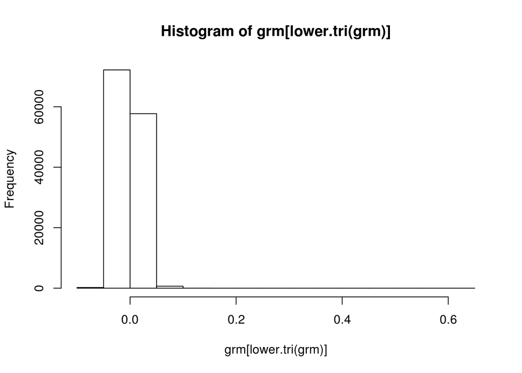

```r
hist(grm[lower.tri(grm)])
```

Remove the individuals that are more than 0.1 related to each other.

```r
# Remove individuals that show a relatedness value more than 0.1
relatedness_indice <- which(grm > 0.1, arr.ind=TRUE) #find the indices in the matrix.

relatednes_individuals <- unique(relatedness_indice[relatedness_indice[,1] != relatedness_indice[,2],][,1]) #make sure not to remove individuals which are compared as the same.

# For simplicity's sake, we remove all related individuals.
# and apply the relatedness filter.
relatedness_filter <- rep(FALSE, num_individuals)
relatedness_filter[relatednes_individuals] <- TRUE

#Check the number of related individuals
genotype_matrix_relatedness_filtered <- genotype_matrix_geno_qc[!relatedness_filter,]
dim(genotype_matrix_relatedness_filtered)
```

```
## [1]    501 114404
```

Q9: How many individuals should be excluded due to relatedness?

## Step 3.2: Perform PCA on the individuals and identify population outliers

```r
principal_components <- prcomp(grm) # relatively easy in R.
```

Now, we can plot the first two principal components.

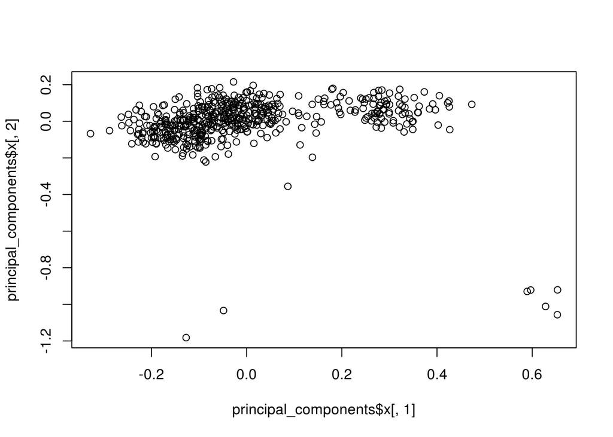

```r
plot(principal_components$x[,1], principal_components$x[,2]) # plot the first two principal components
```

Using some arbitrary threshold, we can now filter the full matrix

```r
#We decide on a threhold for the principal components to filter on

pca_filter <- principal_components$x[,2] < -0.25

#Identify the individuals that show PCAs < -0.25
rownames(genotype_matrix_geno_qc)[pca_filter]
```

```
## [1] "HG01378_HG01378" "NA18519_NA18519" "NA18520_NA18520" "NA18528_NA18528"
## [5] "NA18530_NA18530" "NA18948_NA18948" "NA18949_NA18949" "NA18950_NA18950"
```

```r
#Check how many individuals are identified as population outliers
genotype_matrix_pcas_filtered <- genotype_matrix_geno_qc[!pca_filter,]
dim(genotype_matrix_pcas_filtered)
```

```
## [1]    504 114404
```

Q10: How many individuals are identified as population outliers from PCA analysis?

```r
#Remove individuals from the genotype matrix based on relatedness and PCA, and we have concluded our QC steps
genotype_matrix_post_qc <- genotype_matrix_geno_qc[!pca_filter & !relatedness_filter,]

#Also, remove these individuals from the phenotypes.
phenotypes_post_qc <- phenotypes[!pca_filter & !relatedness_filter]

dim(genotype_matrix_post_qc) # leaves 500 individuals! 114404 variants!
```

```
## [1]    500 114404
```

Q11: How many individuals remain after quality control per individual?